# Data visualization best practices

GEOG 30323: Data Analysis & Visualization

Dr. Kyle Walker

2026-11-03

## Data visualization

- Thus far: we’ve learned how to use data visualization to explore our data
- In the weeks to come:
  - Best practices in data visualization
  - Advanced chart types
  - Interactive visualization
  - Geographic visualization (maps!)
  - Putting it all together!

[figure not shown]

Source: Charles Minard (1869)

[figure not shown]

Source: Wikimedia Commons

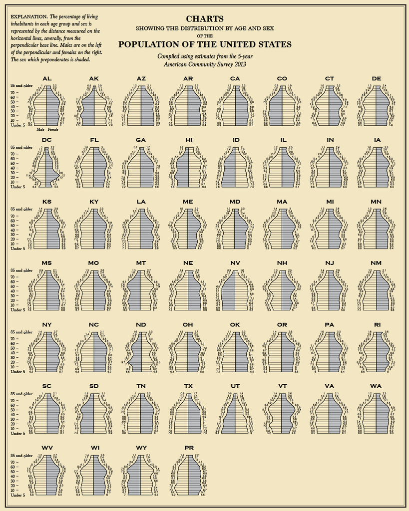

Source: Nathan Yau/FlowingData

### Anscombe’s Quartet

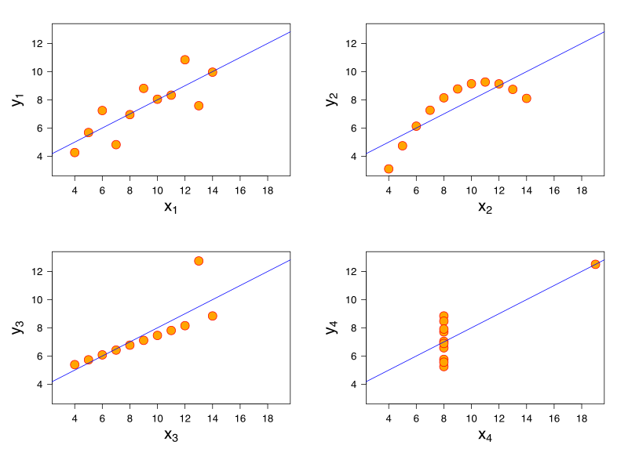

Source: Wikimedia Commons

### Considerations when visualizing data

- What are you visualizing?
- Who is your audience?
- In what format will you be presenting the visualization?

### Visual variables

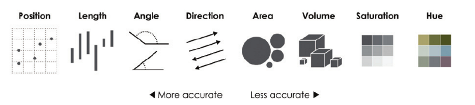

Source: *Data Points*

## Color

- Hue: color, commonly understood (red, blue, green)
- Lightness or Value: extent to which color is light or dark
- Saturation: vividness of the color

## Color schemes

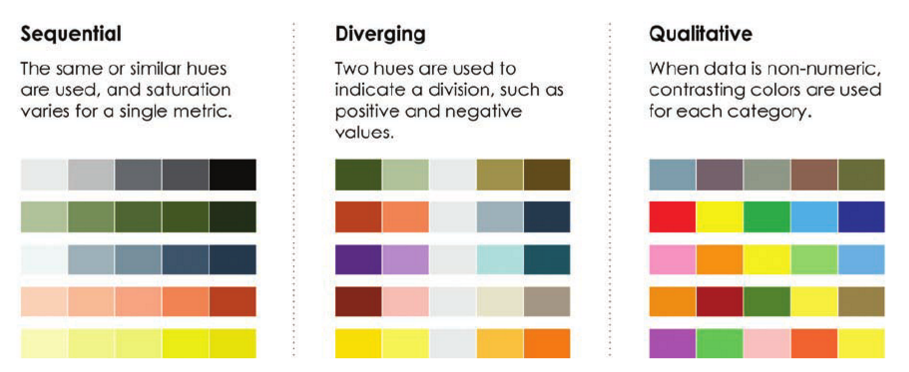

Source: *Data Points*

### Color and context

[figure not shown]

Source: FiveThirtyEight (2014)

## Color-blindness

[figure not shown]

Source: SBNation.com

### Good use of color

[figure not shown]

Source: Kirk Goldsberry/*Grantland*

### Poor use of color

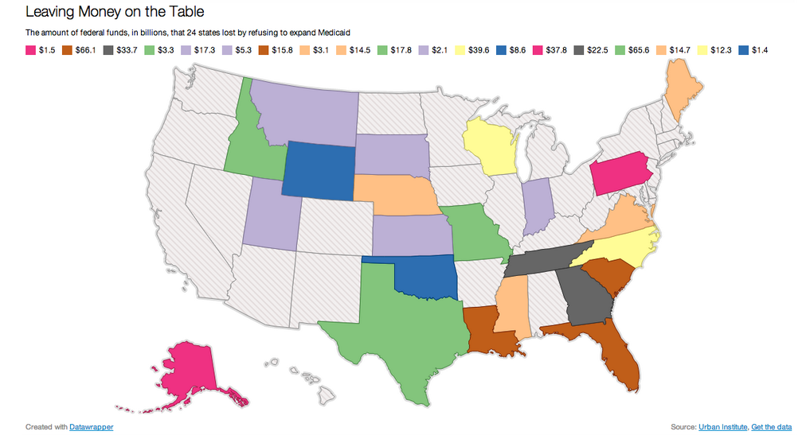

Source: Jonathan Cohn via Kenneth Field/[Cartonerd](http://cartonerd.blogspot.com/2014/08/the-reason-for-cartography.html)

### Color and visual variables

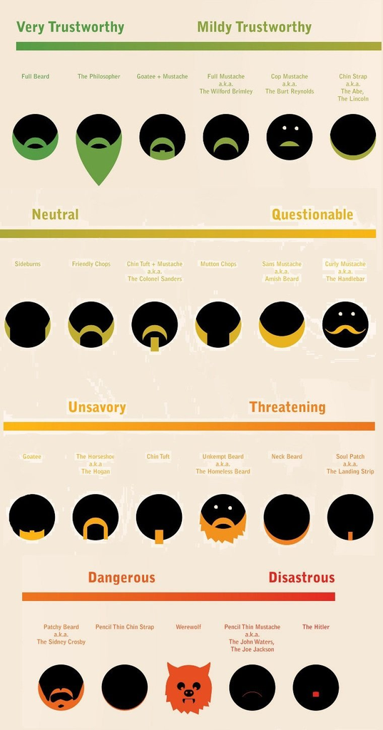

[Image link/source](http://pixelspread.com/images/beards_trust_2.jpg)

## Data for examples

```python
import seaborn as sns
import pandas as pd
import matplotlib.pyplot as plt
from pandas_datareader import wb
sns.set_theme(style = "whitegrid", rc = {"figure.figsize": (10, 8)})

eu_countries = ['AT', 'BE', 'BG', 'HR', 'CY', 'CZ', 'DK', 'EE', 'FI', 'FR',
                'DE', 'GR', 'HU', 'IE', 'IT', 'LV', 'LT', 'LU', 'MT', 'NL',
                'PL', 'PT', 'RO', 'SK', 'SI', 'ES', 'SE']

ue = wb.download(indicator = "SL.UEM.TOTL.ZS",
                 country = eu_countries, start = 1991,
                 end = 2025)

ue.reset_index(inplace = True)
ue.columns = ['country', 'year', 'unemployment']
# Convert the year to integer for better labels
ue = ue.assign(year = ue.year.astype(int))
```

## The ‘heat map’

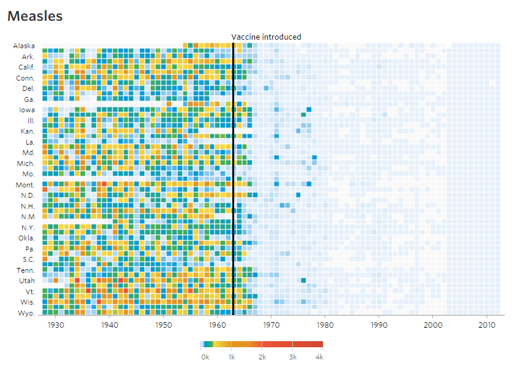

Source: [*The Wall Street Journal*](http://graphics.wsj.com/infectious-diseases-and-vaccines/)

## Heat maps in `seaborn`

- Available in `seaborn`’s `heatmap()` function; takes a wide data frame with y-values in the index and x-values as column headers

```python
ue_wide = ue.pivot(index = 'country', columns = 'year',
                   values = 'unemployment')

sns.heatmap(ue_wide)
```

### The `seaborn` ‘heat map’

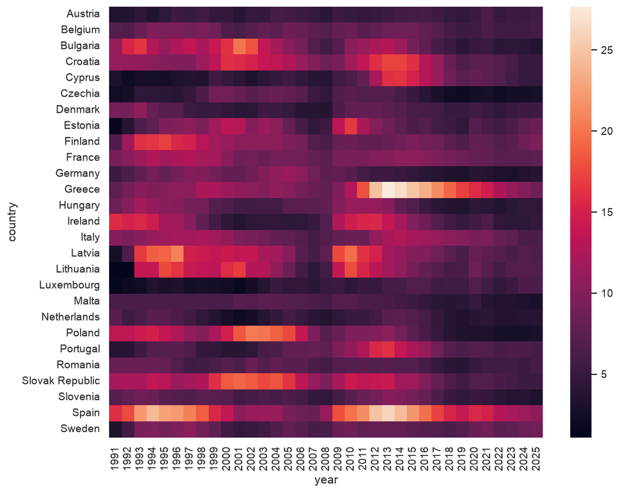

### Color palettes in `seaborn`

- ColorBrewer: popular color schemes for visualization
- Support for ColorBrewer built into `seaborn`; available in the `color_palette()` function
- See more at https://colorbrewer2.org/

### Color in `seaborn`

```python
ue25 = (ue
  .query('year == 2025')
  .sort_values('unemployment',
                ascending = False)
)

sns.barplot(x = 'unemployment', y = 'country',
            data = ue25, hue = 'country',
            palette = "Greens_r", legend = False)
```

### Color in `seaborn`

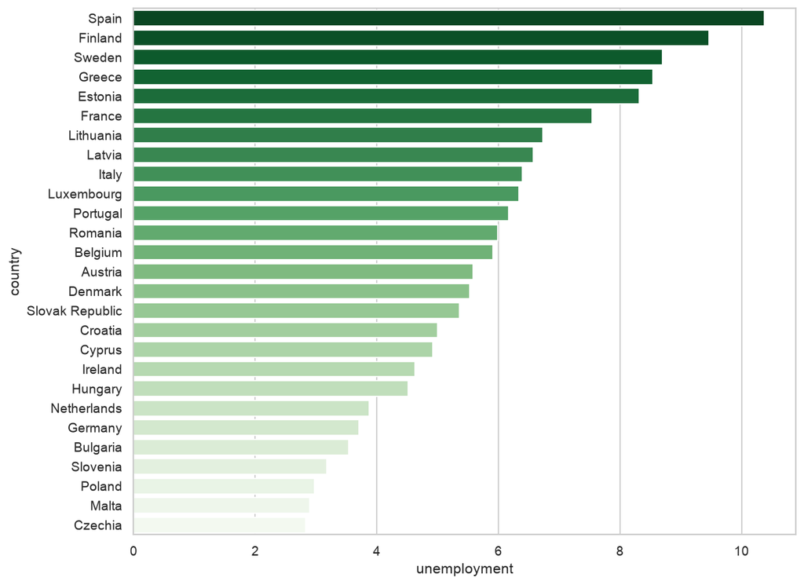

### Highlighting and annotation

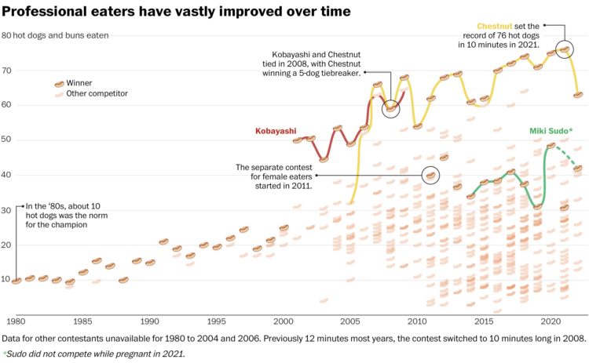

Source: Nathan Yau/[FlowingData](https://flowingdata.com/2023/07/03/competitive-hot-dog-eating-requirements/)

### The “spaghetti” chart

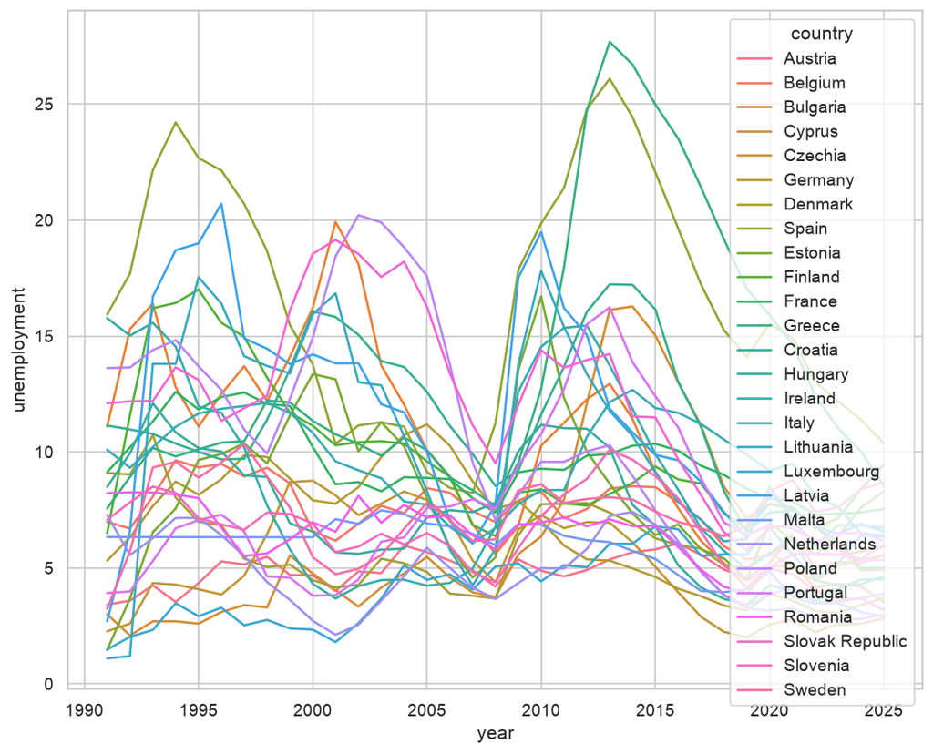

```python
sns.lineplot(data = ue, x = "year", y = "unemployment",
             hue = "country")
```

## Highlighting

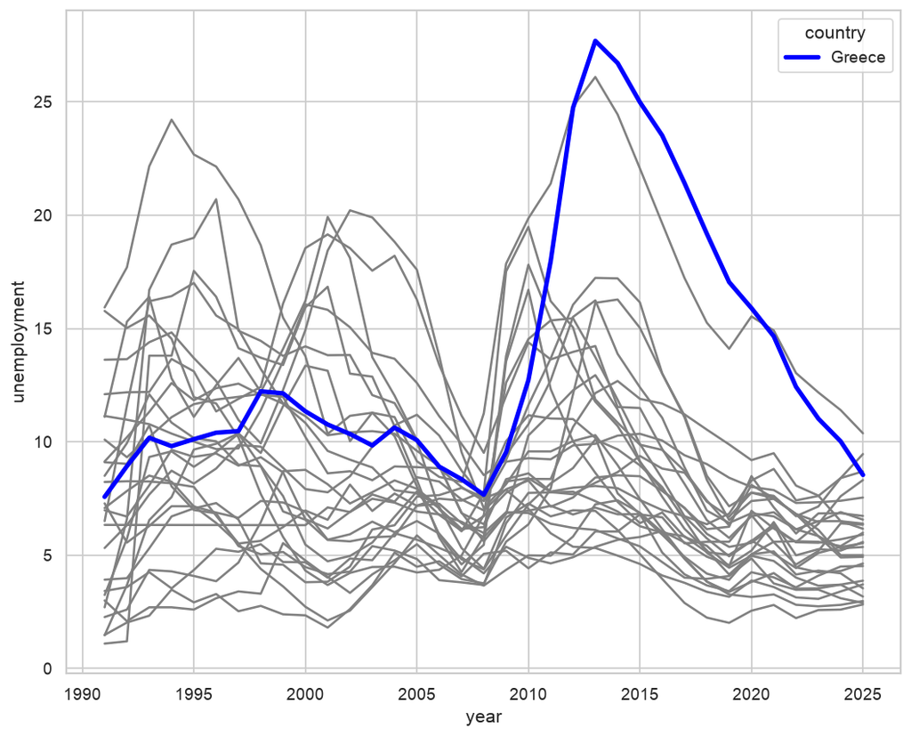

### Highlighting code

```python
# Make a Greece-only dataset
greece = ue.query('country == "Greece"')
# Plot every country in grey, first
sns.lineplot(data = ue, x = "year", y = "unemployment",
             units = "country", estimator = None,
             color = "grey")
# Then, plot Greece on top
sns.lineplot(data = greece, x = "year", y = "unemployment",
             hue = "country", palette = ["blue"], linewidth = 3)
```

### Annotation in Python

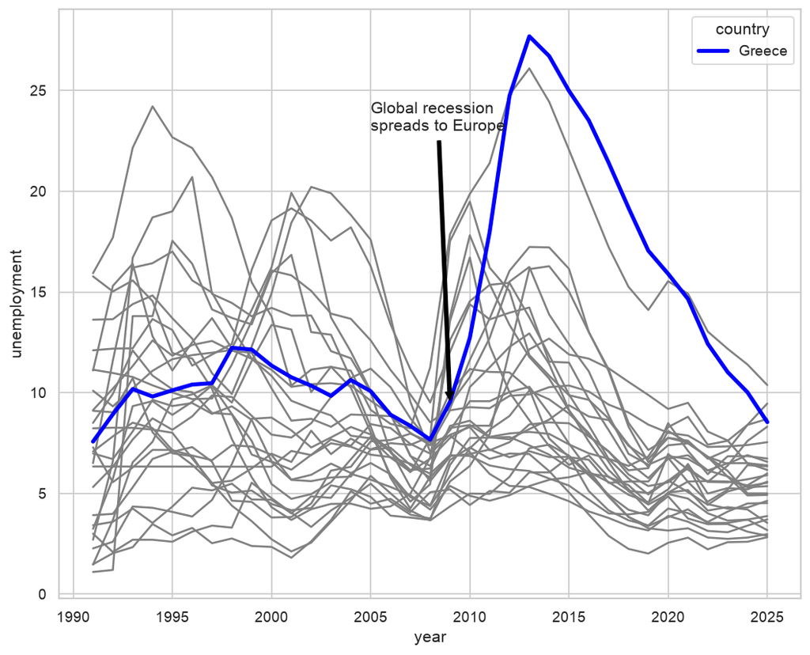

### Annotation code

```python
plt.annotate('Global recession \nspreads to Europe', xy = (2009, 9.5),
             xycoords = 'data', xytext = (2005, 23), textcoords = 'data',
             arrowprops = dict(arrowstyle = 'simple', color = '#000000'))
```

### Text as legend

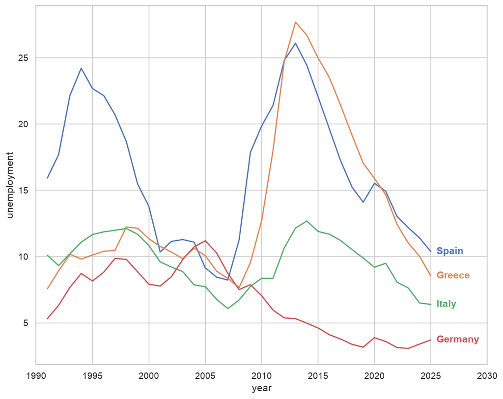

### Text as legend code

```python
countries = ["Spain", "Greece", "Italy", "Germany"]
four = ue[ue["country"].isin(countries)]
sns.lineplot(data = four, x = "year", y = "unemployment",
             hue = "country", hue_order = countries, legend = False)
# Label each line at its end, in the matching color
end = four.query('year == 2025').set_index('country')
for country, color in zip(countries, sns.color_palette()):
    plt.text(2025.5, end.loc[country, 'unemployment'], country,
             color = color, va = 'center', fontweight = 'bold')
# Make room for the labels
plt.xlim(1990, 2030)
```

### Small multiples

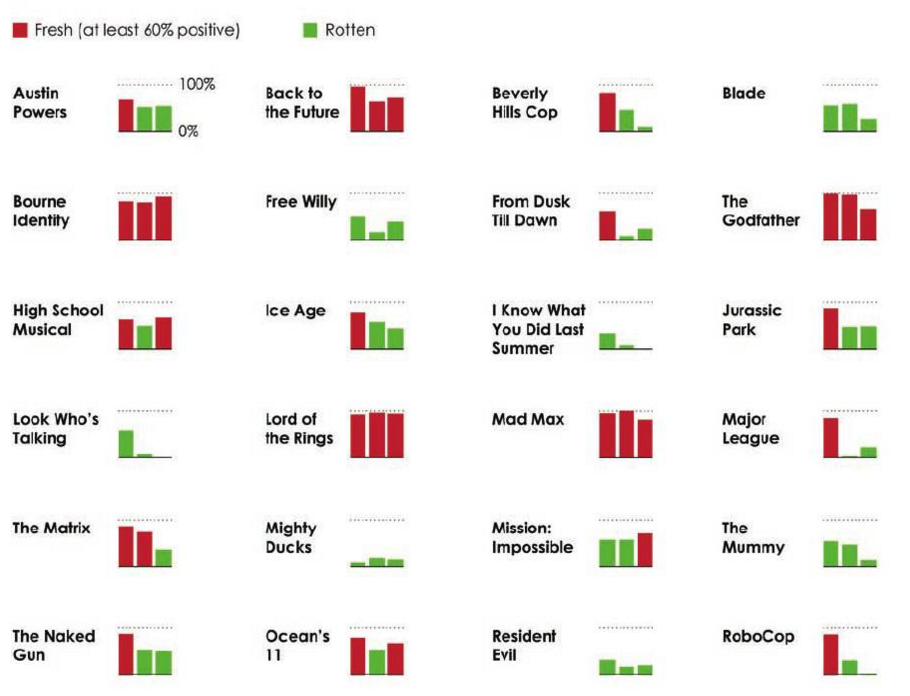

Source: *Data Points*

### Small multiples in Python

```python
ue.sort_values("country", inplace = True)

sns.relplot(data = ue, x = "year", y = "unemployment",
            col = "country", col_wrap = 7,
            kind = "line", height = 2.5)
```

### Small multiples in Python

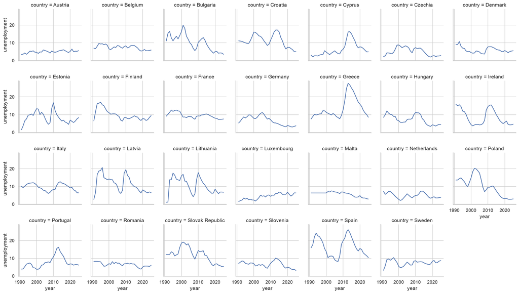

### Modifying chart options

- `seaborn` is a wrapper around `matplotlib`, the main plotting engine for Python
- In turn, all `matplotlib` customization methods are available for your `seaborn` plots - and there are many!
- To get access: `import matplotlib.pyplot as plt`

### Formatting axes & labels

- Example:

```python
plt.figure(figsize = (10, 7))

sns.heatmap(ue_wide, cmap = 'YlGnBu')

plt.ylabel("")
plt.xlabel("")
plt.title("Unemployment in Europe, 1991-2025")
plt.xticks(rotation = 45)
```

### Modified heatmap

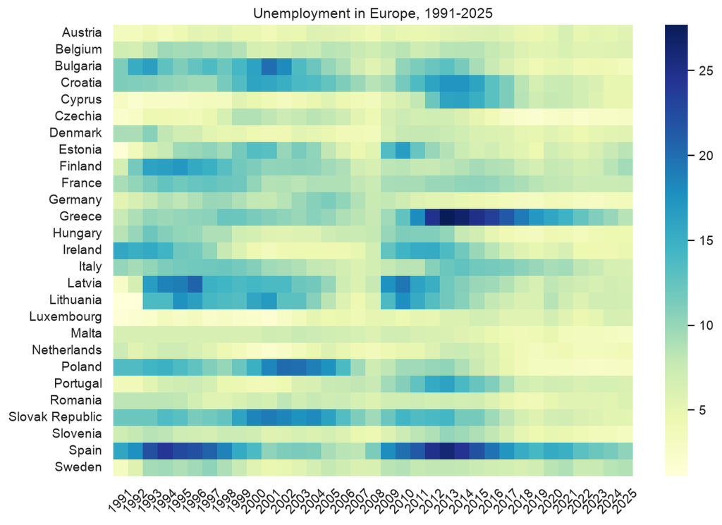

### `seaborn` and `matplotlib`

- `seaborn` returns a `matplotlib` object that can be modified by the options in the `pyplot` module
- Often, these options are wrapped by `seaborn` and available as arguments - so check the documentation to see what you can do!

### Image resolution

- Higher **resolution**: greater detail in an image
- Commonly: *dpi* (dots per inch)

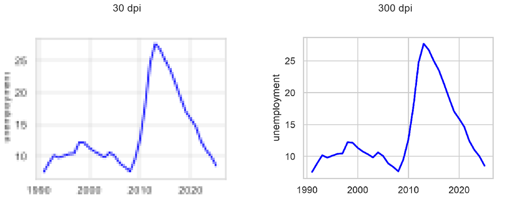

### Exporting your visualizations

- To save your visualizations from Colab:

```python
plt.savefig('destfile.jpg', dpi = 300)
```